# Estatística Inferencial e Distribuição Normal

Fundamentos da Inferência Estatística  
Análise de Dados Ambientais

Luiz Diego Vidal Santos

## Roteiro da Aula

- 1 Estatística Inferencial
- 2 Testes de Hipóteses
- 3 Inferência Frequentista (valor-*p*)
- 4 Erros Tipo I e Tipo II
- 5 Tamanho da Amostra e Poder
- 6 Distribuição Normal
- 7 Desvios de Normalidade
- 8 Testes de Normalidade

**Objetivo:** Compreender os fundamentos da inferência estatística, os riscos de erros nas decisões e as propriedades da distribuição normal.

# 1 — ESTATÍSTICA INFERENCIAL

## O que é Estatística Inferencial?

**Definição**

Inferência estatística refere-se aos resultados derivados da **análise estatística** dos dados coletados.

A inferência advém da relação entre a **teoria estatística** e os **dados reais**.

**Métodos de inferência para testes de hipóteses:**

1 Inferências frequentistas (TSHN; *p*-value; *p* < 0,05)

2 Estimação Bayesiana

3 Estimação por *Bootstrapping* (IC das diferenças/magnitudes)

# 2 — TESTES DE HIPÓTESES

## Hipóteses Científicas

**Hipótese** — Uma expectativa sobre as características morfológicas de uma nova cultivar.

**Exemplo:** A cultivar Abacaxi BRS Ajubá apresenta maior nível de controle da fusariose que a cultivar BRS Vitória.

**Teste de hipótese** — Avaliação, por meio de métodos científicos, da hipótese estabelecida.

## Passo a Passo

**Etapas para teste de hipóteses:**

1 Crie uma ou mais **hipóteses**

2 Colete dados **úteis** para testá-las

3 Analise os dados com **testes estatísticos** adequados

4 Avalie os resultados para ver se **suportam** as hipóteses

## Ho e Ha

Ao coletar dados, você se depara com **duas possibilidades**:

**Hipótese Nula (Ho)**

O efeito **não existe**.

É a hipótese que se busca **rejeitar**.

**Hipótese Alternativa (Ha)**

O efeito **existe**.

É a hipótese do **pesquisador**.

# 3 — INFERÊNCIA FREQUENTISTA

## Valor-*p* de Fisher

**Ronald Fisher (1935)**

- Critério probabilístico objetivo: $p < 0{,}05$
- Teste de Significância da Hipótese Nula (TSHN)

. . .

O critério do valor-*p* assume, **arbitrariamente**, uma probabilidade de **5% de chance de erro** na inferência.

[figure not shown]

## Valor-*p* — Exemplo Prático

**Exemplos de inferência com valor-*p*:**

- Vetiver com sistema radicular maior que Paspalum ($p < 0{,}05$)
- Depressão se associou com baixa motivação no laboratório ($p < 0{,}01$)
- Não houve associação entre consumo de maconha e perda de libido ($p = 0{,}18$)
- Associação entre consumo de maconha e diminuição na memória foi marginalmente significativa ($p = 0{,}06$)

## Cuidados com o Valor-*p*

O valor de *p* é **fortemente influenciado** pelo tamanho amostral!

**Mesmo efeito (r = 0,245), diferentes N:**

| N | Valor de *p* | Significativo? |
| --- | --- | --- |
| 10 | 0,495 | Não |
| 20 | 0,298 | Não |
| 50 | 0,086 | Não |
| 70 | 0,041 | **Sim** |
| 150 | 0,003 | **Sim** |

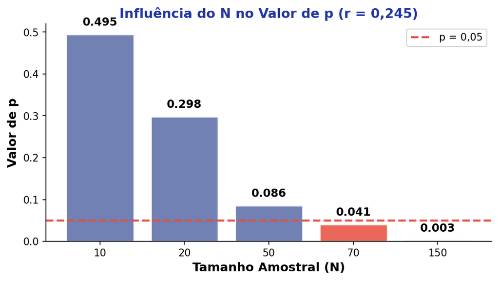

O valor de *p* **não reflete**, por si só, a **magnitude** do efeito.

# 4 — ERROS TIPO I E TIPO II

## Matriz de Decisão

Ao tomar decisões sobre Ho, há **duas formas de errar**:

**Erro Tipo I** ($\alpha$)

Rejeitar Ho quando Ho é **verdadeira**.

→ “Afirmo que há efeito, quando **não há**.”

. . .

**Erro Tipo II** ($\beta$)

Aceitar Ho quando Ho é **falsa**.

→ “Afirmo que não há efeito, quando **há**.”

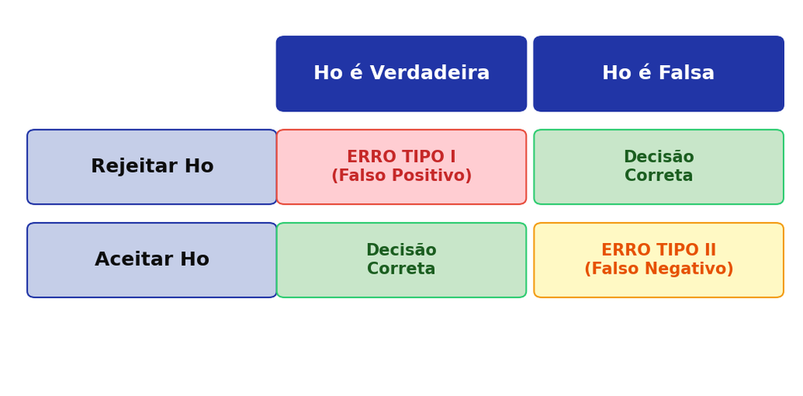

## Outras Causas de Erro

Situações que nos levam a cometer Erro Tipo I e Erro Tipo II:

**Pressupostos**

Testes estatísticos cujos pressupostos **não foram acatados**.

**Amostras**

Amostras problemáticas com **vieses de seleção**.

**Instrumento**

Instrumento de pesquisa **ruim** ou não validado.

# 5 — TAMANHO DA AMOSTRA E PODER

## Poder Amostral

**Poder amostral** — Probabilidade de detectar um efeito do tratamento, **se estiver presente**.

$$\text{Poder} = 1 - \beta = 1 - 0{,}20 = 0{,}80$$

(Cohen, 1988, 1992)

. . .

**Valores aceitos na literatura:**

- $\alpha = 0{,}05$ (significância)
- Poder $= 0{,}80$ (80%)

**Tamanho do efeito ($d_z$)**

O $d_z$ é uma medida padronizada da diferença entre duas condições em um estudo de medidas repetidas.

Quanto **maior** o $d_z$, mais facilmente detectável é a diferença, necessitando de **menos amostras**.

. . .

**Ferramenta:** [G*Power](https://www.psychologie.hhu.de/arbeitsgruppen/allgemeine-psychologie-und-arbeitspsychologie/gpower) para cálculo de tamanho amostral.

## Relação N × Efeito × Decisão

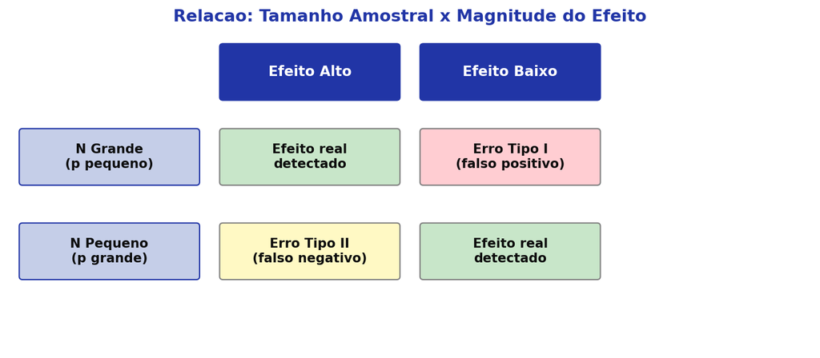

Com **N grande** e efeito baixo → risco de **Erro Tipo I** (falso positivo).

Com **N pequeno** e efeito alto → risco de **Erro Tipo II** (falso negativo).

# 6 — DISTRIBUIÇÃO NORMAL

## O que é a Distribuição Normal?

**Definição**

A Distribuição Normal é uma das distribuições de probabilidade mais utilizadas para modelar **fenômenos naturais**.

Um grande número de fenômenos naturais apresenta esse tipo de distribuição.

. . .

A curva normal representa a forma como diferentes valores se **agrupam em torno** de um determinado ponto.

**Definida por dois parâmetros:**

- **Média** ($\bar{X}$) — centro da distribuição
- **Desvio-padrão** ($DP$) — largura/dispersão

## Exemplo — Capim Vetiver

**Dados:** Tamanho radicular do Capim Vetiver

| Medição | cm |
| --- | --- |
| 1 | 55 |
| 2 | 64 |
| 3 | 70 |
| 4 | 72 |
| 5 | 74 |
| 6 | 80 |
| 7 | 98 |
| 8 | 100 |

**Média:**

$$\bar{X} = \frac{613}{8} = 76{,}62 \text{ cm}$$

## Regra Empírica (68–95–99)

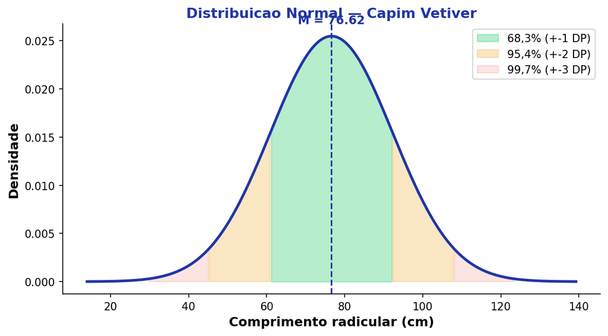

**±1 DP (68,3%)**

$[60{,}96 - 92{,}28]$

**±2 DP (95,4%)**

$[45{,}30 - 107{,}94]$

**±3 DP (99,7%)**

$[29{,}64 - 123{,}60]$

# 7 — DESVIOS DE NORMALIDADE

## Assimetria

**Assimetria (Skewness)** — Mede o grau de **desvio da simetria** da distribuição.

[figure not shown]

**Exemplo real:** A distribuição de renda no Brasil é **assimétrica positiva** — muitas pessoas com renda baixa e poucas com renda alta.

## Curtose

**Curtose (Kurtosis)** — Mede o grau de **achatamento** da distribuição.

[figure not shown]

**Leptocúrtica**

Dados muito **concentrados** junto à média.

**Mesocúrtica**

Distribuição **normal** (referência).

**Platicúrtica**

Dados muito **dispersos**; muitos valores afastados da média.

# 8 — TESTES DE NORMALIDADE

## Critérios Descritivos

**Critérios descritivos** (Tabachnick & Fidell, 2019)

**Procedimento:** Transformar o escore de Assimetria e Curtose em **escore Z**:

$$Z = \frac{\text{Assimetria (ou Curtose)}}{\text{Erro-padrão}}$$

$|Z| > 1{,}96$

$p < 0{,}05$

$|Z| > 2{,}58$

$p < 0{,}01$

$|Z| > 3{,}29$

$p < 0{,}001$

## Critérios Estatísticos

Nos testes K-S e S-W, espera-se $p > 0{,}05$ para **acatar** a normalidade.

## Hierarquia de Poder dos Testes

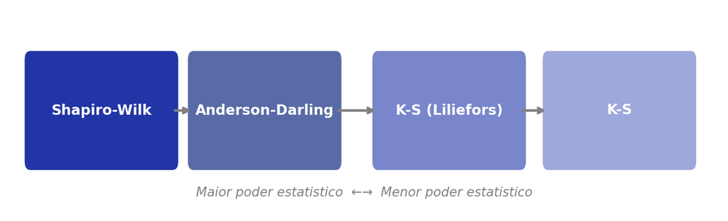

**Recomendação:** Prefira o **Shapiro-Wilk** quando possível — é o teste com maior poder estatístico para detectar desvios de normalidade.

Obrigado!

Luiz Diego Vidal Santos

Universidade Estadual de Feira de Santana (UEFS)